# New Biomass Pools Workflow

Sarah Gaichas

2023-08-22

```r
library(here)
library(stringr)
library(magrittr)
library(dplyr)
library(tidyr)
library(ggplot2)
library(atlantisom)
```

## Intro

Current `atlantisom` functions are designed primarily for age structured modeled groups, because the package was originally scoped to generate simulated data to test fishery stock assessments. It is now clear that simulated data testing can also benefit other model types, including multispecies models and food web models. Therefore, there is a need to develop functions to develop simulated data for lower trophic level biomass pools modeled in Atlantis and also included in food web models such as Rpath.

Where is biomass information for non-age structured groups output? To be parallel to survey sampling for fish, it would be good to have it by model output timestep toutinc and polygon, but depth layer is not necessary at this time.

First check content of the `.nc` output file:

```r
dir <- here("atlantisoutput/NOBA_sacc_30")
file_nc <- "nordic_runresults_01.nc"

file.nc <- file.path(dir, file_nc)

 # Load ATLANTIS output!
  at_out <- RNetCDF::open.nc(con = file.nc)
  #on.exit(RNetCDF::close.nc(at_out))

    # Get info from netcdf file! (Filestructure and all variable names)
  var_names_ncdf <- sapply(seq_len(RNetCDF::file.inq.nc(at_out)$nvars - 1),
    function(x) RNetCDF::var.inq.nc(at_out, x)$name)
  n_timesteps <- RNetCDF::dim.inq.nc(at_out, 0)$length
  n_boxes     <- RNetCDF::dim.inq.nc(at_out, 1)$length
  n_layers    <- RNetCDF::dim.inq.nc(at_out, 2)$length
```

Which species are biomass pools, are they identified in the groups.csv?

No, biomass pools are defined as the combination of NumCohorts == 1 and GroupType not FISH, FISH_INVERT, SHARK, BIRD, MAMMAL, REPTILE. Biomass pools groups are among those below according to the Atlantis manual, ch 6. p 106:

> BIOMASS POOL GROUPS  
> Phytoplankton  
> 7) Small Phytoplankton SM_PHY  
> 8) Large Phytoplankton LG_PHY (used in combination with IsSiliconDep to define diatoms)  
> 9) Trichodesmium and Cyanobacteria TRICHO (N fixers)  
> Other primary producers  
> 10) Microphtybenthos MICROPHTYBENTHOS  
> 11) Dinoflagellates DINOFLAG  
> 12) Phytoben PHYTOBEN (typically used to represent macroalgae)  
> 13) Seagrass SEAGRASS  
> 14) Turf TURF  
> Zooplankton  
> 15) Small Zooplankton SM_ZOO  
> 16) Medium Zooplankton MED_ZOO  
> 17) Large Zooplankton LG_ZOO  
> 18) Jellyfish JELLIES (in the past represented as LG_ZOO)  
> Large pelagic invetebrates  
> 19)Cephalopod CEP  
> 20) Prawns PWN  
> Infauna  
> 21) Small Infauna SM_INF  
> 22) Large Infauna LG_INF  
> Epibenthic organisms  
> 23) Sediment epibenthic filter feeders SED_EP_FF (often used for bivalves, sponges)  
> 24) Benthic grazers SED_EP_OTHER  
> 25) Mobile epibenthos MOB_EP_OTHER (often used for crabs, lobster, octopus)  
> 26) Corals CORAL  
> 27)Sponges SPONGE  
> Bacteria  
> 28) Pelagic Bacteria PL_BACT  
> 29) Sediment Bacteria SED_BACT  
> Obligatory detritus groups  
> 30) Carrion CARRION  
> 31) Labile detritus LAB_DET  
> 32) Refractory detritus REF_DET  
> 33) Additional ice and land based groups are also available.  
> Ice dwelling  
> 34) ICE_BACT  
> 35) ICE_MIXOTROPHS  
> 36) ICE_DIATOMS  
> 37) ICE_ZOOBIOTA  
> Land dwelling (vegetation only for now)  
> 38) MARSH  
> 39) MANGROVE

For NOBA Atlantis, these are the biomass pools:

```r
fgs <- atlantisom::load_fgs(here("atlantisoutput/NOBA_sacc_30"), "nordic_groups_v04.csv")

pools <- fgs %>%
  dplyr::filter(NumCohorts==1) %>%
  dplyr::select(Code, Name, Long.Name, NumCohorts, InvertType)

knitr::kable(pools)
```

| Code | Name | Long.Name | NumCohorts | InvertType |
| --- | --- | --- | --- | --- |
| KCR | King_crab | Red king crab | 1 | LG_INF |
| ZG | Gel_zooplankton | Gelatinous zooplankton | 1 | LG_ZOO |
| ZL | Large_zooplankton | Large zooplankton | 1 | LG_ZOO |
| ZM | Medium_zooplankton | Medium zooplankton | 1 | MED_ZOO |
| ZS | Small_zooplankton | Small zooplankton | 1 | SM_ZOO |
| DF | Dinoflag | Dinoflagellates | 1 | DINOFLAG |
| PS | Small_phytop | Small phytoplankton | 1 | SM_PHY |
| PL | Large_phytop | Large phytoplankton | 1 | LG_PHY |
| BC | Predatory_ben | Predatory benthos | 1 | LG_INF |
| BD | Detrivore_ben | Detrivore benthos | 1 | LG_INF |
| BFF | Benthic_filterf | Benthic filter feeders | 1 | SED_EP_FF |
| SPO | Sponges | Sponges | 1 | SED_EP_FF |
| COR | Corals | Corals | 1 | SED_EP_FF |
| PB | Pel_bact | Pelagic bacteria | 1 | PL_BACT |
| BB | Ben_bact | Sediment bacteria | 1 | SED_BACT |
| DR | Ref_det | Refractory detritus | 1 | REF_DET |
| DL | Lab_det | Labile detritus | 1 | LAB_DET |
| DC | Carrion | Carrion | 1 | CARRION |

Here are the relevant outputs in the output.nc file for these groups:

```r
# return everything in var_names_ncdf matching Name in pools

var_names_ncdf[str_detect(var_names_ncdf, str_c(pools$Name, collapse ="|"))]
```

```
##  [1] "Large_phytop_N"        "Small_phytop_N"        "Dinoflag_N"
##  [4] "King_crab_N"           "Gel_zooplankton_N"     "Large_zooplankton_N"
##  [7] "Medium_zooplankton_N"  "Small_zooplankton_N"   "Pel_bact_N"
## [10] "Ben_bact_N"            "Detrivore_ben_N"       "Predatory_ben_N"
## [13] "Ref_det_N"             "Lab_det_N"             "Carrion_N"
## [16] "Benthic_filterf_N"     "Sponges_N"             "Corals_N"
## [19] "Benthic_filterf_Cover" "Sponges_Cover"         "Corals_Cover"
```

So we want “N” nitrogen output. In theory this can be achieved with `atlantisom::load_nc`with `select_variable = "N"`. Looks like it works, output is N for our selected biomass pool species over all polygons, layers, and times. Output of `unique(testNpools$species)`:

```r
select_groups <- pools$Name
nc_out <- file_nc
bps <- load_bps(dir = dir, fgs = "nordic_groups_v04.csv", file_init = "nordic_biol_v23.nc")
  # Get the boundary boxes
  allboxes <- load_box(dir = dir, file_bgm = "Nordic02.bgm")
  boxes <- get_boundary(allboxes)



testNpools <- load_nc(dir = dir,
                  file_nc = nc_out,
                  bps = bps,
                  fgs = fgs,
                  select_groups = select_groups,
                  select_variable = "N",
                  check_acronyms = TRUE,
                  bboxes = boxes)
```

```
## [1] "Read /Users/sarah.gaichas/Documents/0_Data/Atlantis/Poseidon/poseidon-dev/atlantisoutput/NOBA_sacc_30/nordic_runresults_01.nc successfully"
```

```r
unique(testNpools$species)
```

```
##  [1] "Benthic_filterf"    "Sponges"            "Corals"
##  [4] "King_crab"          "Gel_zooplankton"    "Large_zooplankton"
##  [7] "Medium_zooplankton" "Small_zooplankton"  "Dinoflag"
## [10] "Small_phytop"       "Large_phytop"       "Predatory_ben"
## [13] "Detrivore_ben"      "Pel_bact"           "Ben_bact"
## [16] "Ref_det"            "Lab_det"            "Carrion"
```

I don’t think we have a function that aggregates over layers and converts N to biomass but there are pieces in other functions.

New `atlantisom` function: `calc_biomass_pool` based on `calc_biomass_age`, but adding the expansion to volume used in `calc_pred_cons`.

```r
# we need the volume of each layer as input to this
vol <- load_nc_physics(dir = dir,
                         file_nc = nc_out,
                         physic_variables = "volume",
                         aggregate_layers = FALSE,
                         bboxes = boxes)

# we need area for the benthic inverts instead of volume
# THANK YOU JOE for this tip
area <- load_boxarea(dir = dir,
                     file_bgm = "Nordic02.bgm")

# we need a list of which group types to expand to area instead of volume
benthos <- c("SED_EP_FF", "SED_EP_OTHER", "SED_BAC",
             "MOB_EP_OTHER", "LG_INF", "SM_INF",
             "MICROPHYTBENTHOS", "SEAGRASS")



calc_biomass_pool <- function(pooln, vol, area, fgs, biolprm){
  datalist <- list(pooln)

  # Conversion factor from mg N to t wet-weight
  # should only use conversion for non vertebrates
  # also need volume of cell info
  bio_conv <- biolprm$redfieldcn * biolprm$kgw2d / 1000000000

  # get fgs info
    # use grouptype column to allocate
  colnames(fgs) <- tolower(colnames(fgs))

  # check for GroupType or InvertType
  if (!("grouptype" %in% colnames(fgs) | "inverttype"%in% colnames(fgs))) {
    stop(paste("The columns GroupType or InvertType ars not in your functional\n",
               "groups file."))
  }

  # change inverttype to grouptype, contents should be the same
  if("inverttype" %in% names(fgs)) names(fgs)[names(fgs) == 'inverttype'] <- 'grouptype'

  fgs$grouptype <- tolower(fgs$grouptype)


  pooltype <- fgs |>
    dplyr::select(species=name, grouptype) |>
    dplyr::mutate(pooltype = dplyr::case_when((grouptype %in% c("lg_inf",
                                                                "sm_inf",
                                                                "sed_bact",
                                                                "sed_ep_ff",
                                                                "sed_ep_other",
                                                                "mobile_ep_other",
                                                                "coral",
                                                                "sponge")) ~ "benthos",
                                              TRUE ~ "nonbenth"))

  data_names <- c("species", "agecl", "polygon", "layer", "time", "atoutput")

  if (all(sapply(datalist, function(x) all(is.element(names(x), data_names))))){

    names(vol)[names(vol) == "atoutput"] <- "vol"

    pooln <- merge(pooln, vol,
                   by = c("time", "polygon", "layer"))

    pooln <- merge(pooln, area,
                   by = c("polygon"))

    pooln <- merge(pooln, pooltype,
                   by = c("species"))

    #pooln$atoutput <- with(pooln, vol * atoutput * bio_conv)

    pooln <- pooln |>
      dplyr::mutate(atoutput = dplyr::case_when(pooltype == "nonbenth" ~ vol * atoutput * bio_conv,
                                                pooltype == "benthos" ~
                                                  ifelse(layer==7, area * atoutput * bio_conv, 0)))

    # Sum over layers
    biomass_pools <- aggregate(atoutput ~ species + agecl + time + polygon,
      data = pooln, sum)
  } else {
    stop(paste("Dataframe names do not match with", data_names))
  }

  return(biomass_pools)
}

biolprm <- load_biolprm(dir = dir, file_biolprm = "nordic_biol_incl_harv_v_011_1skg.prm")
biomass_pools <- calc_biomass_pool(pooln = testNpools,
                                   vol = vol,
                                   area = area,
                                   fgs = fgs,
                                   biolprm = biolprm)
```

Do the new biomass pools match the `BiomIndx.txt` output when aggregated over polygon? If so they can be the input to the survey function for time and spatial subsetting.

```r
aggbiopools <- biomass_pools %>%
  dplyr::group_by(species, agecl, time) %>%
  dplyr::summarise(totpool = sum(atoutput))
```

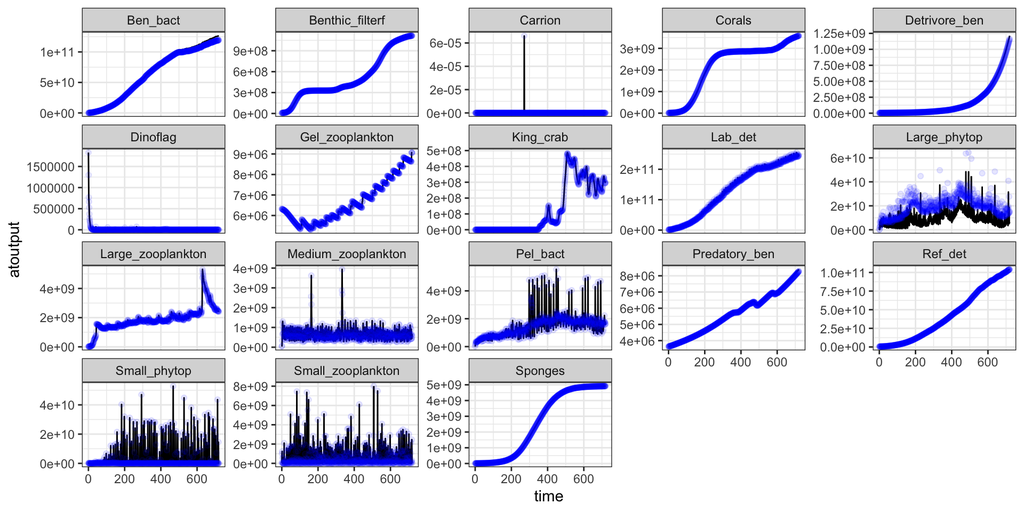

```r
txtbiopools <- atlantisom::load_bioind(dir, "nordic_runresults_01BiomIndx.txt", fgs) %>%
  dplyr::mutate(time = time/73) %>%
  dplyr::filter(species %in% unique(aggbiopools$species)) %>%
  dplyr::select(species, time, atoutput)

ggplot(txtbiopools, aes(x=time, y=atoutput)) +
  geom_line() +
  geom_point(data = aggbiopools, aes(x = time, y = totpool), colour = "blue", alpha=0.1) +
  theme_bw() +
  facet_wrap(~species, scales = "free_y")
```

## Diagnose mismatches between biopools and BiomInd.txt output

Joe pointed out that benthic groups should be expanded to area rather than volume. That correction has now been applied, and matches are better, but still diverge over time for some groups.

Groups that match seem more likely to be pelagic (dinoflagellates, all zooplankton, pelagic bacteria, labile and refractive detritus) although large phytoplankton is way off.

```r
mismatch <- txtbiopools |>
  dplyr::left_join(aggbiopools) |>
  dplyr::mutate(mismatch = atoutput - totpool,
                bad = ifelse(abs(mismatch) > 0.01*(atoutput), 1, 0))
```

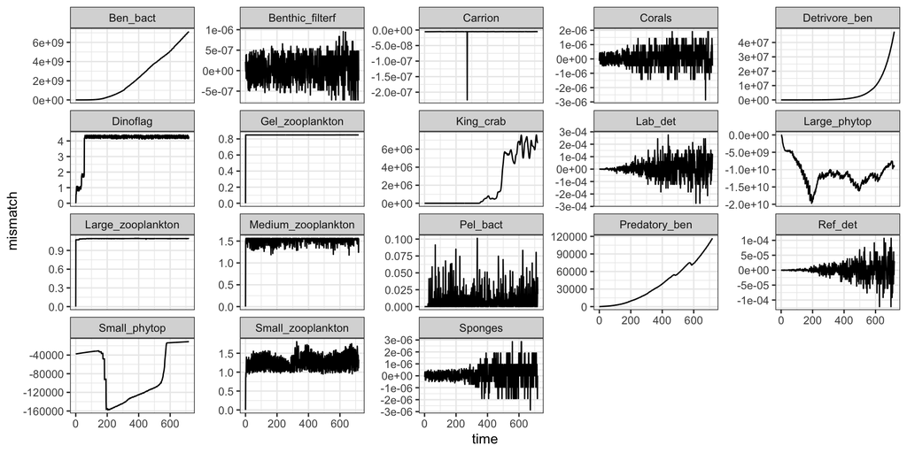

```r
ggplot(mismatch, aes(x=time, y=mismatch)) +
  geom_line() +
  theme_bw() +
  facet_wrap(~species, scales = 'free_y')
```

This is mismatch coded as 0 if less than 1% of txt output, 1 if more. Those exceeding are carrion, predatory benthos, detritivore benthos, king crab, benthic bacteria, large phytoplankton and sometimes small zooplankton.

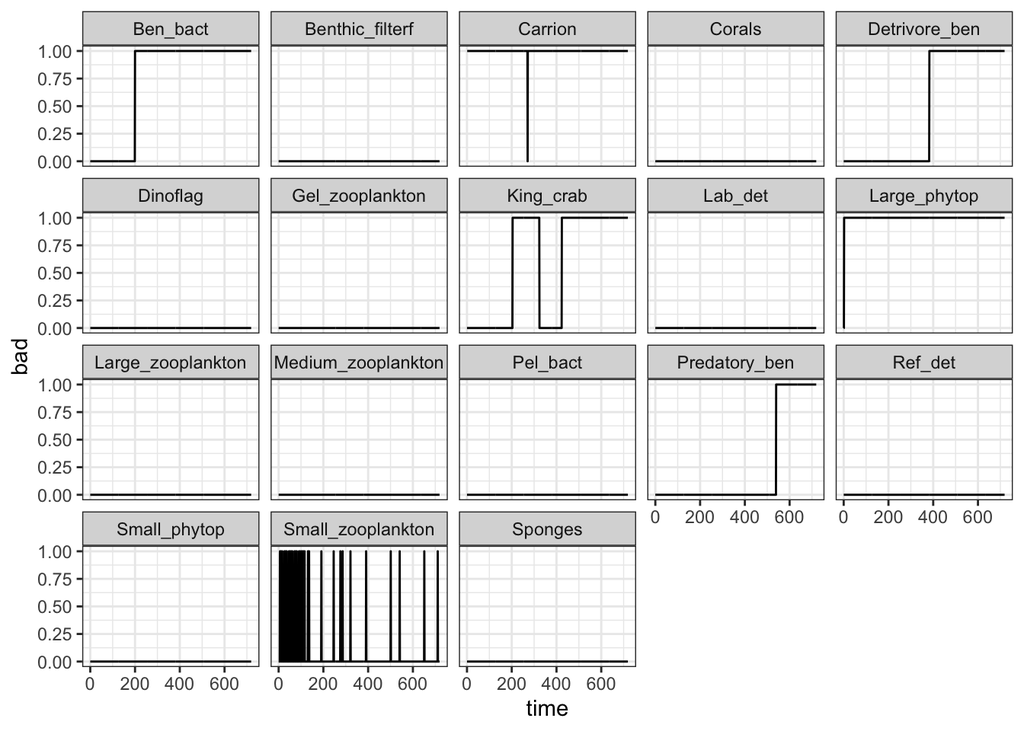

```r
ggplot(mismatch, aes(x=time, y=bad)) +
  geom_line() +
  theme_bw() +
  facet_wrap(~species)
```

What is up with the phytoplankton groups? Small matches well visually but large doesn’t. Large phytoplankton is the largest magnitude mismatch across all groups.

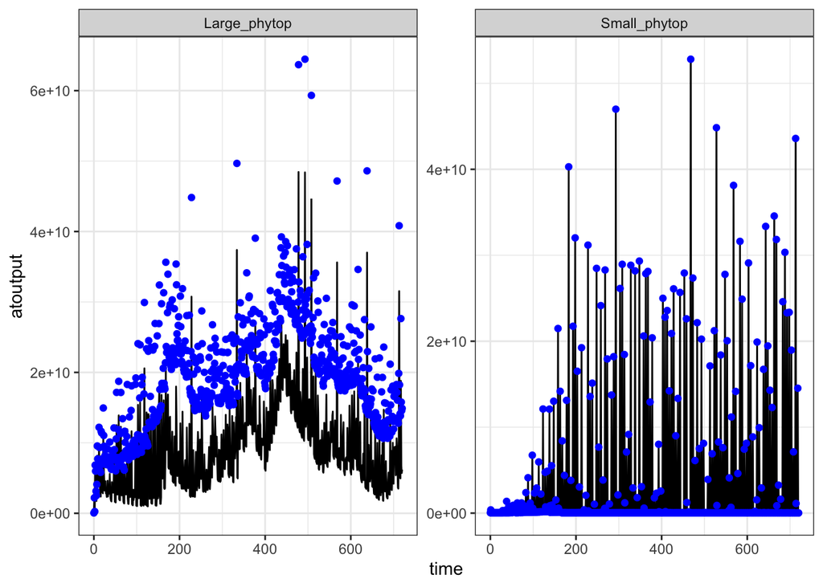

```r
ggplot(txtbiopools |> filter(species %in% c("Large_phytop", "Small_phytop")),
       aes(x=time, y=atoutput)) +
  geom_line() +
  geom_point(data = aggbiopools |> filter(species %in% c("Large_phytop", "Small_phytop")),
             aes(x = time, y = totpool), colour = "blue") +
  theme_bw() +
  facet_wrap(~species, scales = "free_y")
```

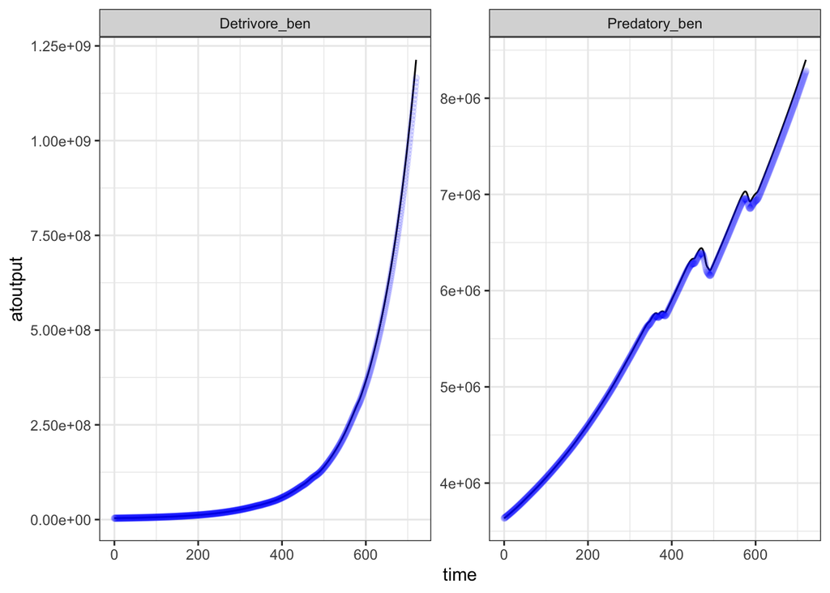

```r
ggplot(txtbiopools |> filter(species %in% c("Predatory_ben", "Detrivore_ben")),
       aes(x=time, y=atoutput)) +
  geom_line() +
  geom_point(data = aggbiopools |> filter(species %in% c("Predatory_ben", "Detrivore_ben")),
             aes(x = time, y = totpool), colour = "blue", alpha=0.1) +
  theme_bw() +
  facet_wrap(~species, scales = "free_y")
```

## Remaining changes to workflow, once corrected

### Add `calc_biomass_pool` to `run_truth`

### Test wrapper functions with biomass pool groups